# Esimene kodutöö - andmelüngad

Elina Prints

20.02.2022

# Andmelünkade uurimine

Laen sisse Euroopa Sotsiaaluuringu Eesti 9. laine andmed (2018):

```
Tunnused B6-B12:
trstprl    - Trust in country's parliament
trstlgl    - Trust in the legal system
trstplc    - Trust in the police
trstplt    - Trust in politicians
trstprt    - Trust in political parties
trstep     - Trust in the European Parliament
trstun     - Trust in the United Nations

Muud tunnused:
gndr       - Gender
agea       - Age
brncntr    - Born in country
rlgdgr     - How religious are you
eduyrs     - Years of full-time education completed
```

```r
ee9 <- read_sav("ESS9EE.sav")
andmed <- ee9 %>%
  select(trstprl,trstlgl,trstplc,trstplt,trstprt,trstep,trstun,gndr,agea,brncntr,rlgdgr,eduyrs)
```

**Kui palju on nende tunnuste peale täielikult mõõdetud indiviide? Kui suur on andmelünkadega indiviidide osakaal (st nende indiviidide osakaal, kellel on vähemalt ühes tunnuses andmelünk)? Millistes tunnustes on lünki rohkem, millistes vähem?**

```r
sum(complete.cases(andmed)) # Täielikult mõõdetud indiviidide arv
```

```
## [1] 1706
```

```r
sum(!complete.cases(andmed)) # Andmelünkadega indiviidide arv ehk indiviidide arv, kellel on vähemalt ühes tunnuses andmelünk
```

```
## [1] 198
```

```r
miss_var_summary(andmed)
```

```
## # A tibble: 12 × 3
##    variable n_miss pct_miss
##    <chr>     <int>    <dbl>
##  1 trstun      153    8.04
##  2 trstep      131    6.88
##  3 trstlgl      27    1.42
##  4 trstprt      23    1.21
##  5 trstplt      19    0.998
##  6 trstprl      14    0.735
##  7 trstplc       6    0.315
##  8 rlgdgr        6    0.315
##  9 gndr          0    0
## 10 agea          0    0
## 11 brncntr       0    0
## 12 eduyrs        0    0
```

```r
miss_var_table(andmed)
```

```
## # A tibble: 8 × 3
##   n_miss_in_var n_vars pct_vars
##           <int>  <int>    <dbl>
## 1             0      4    33.3
## 2             6      2    16.7
## 3            14      1     8.33
## 4            19      1     8.33
## 5            23      1     8.33
## 6            27      1     8.33
## 7           131      1     8.33
## 8           153      1     8.33
```

```r
miss_case_table(andmed)
```

```
## # A tibble: 8 × 3
##   n_miss_in_case n_cases pct_cases
##            <int>   <int>     <dbl>
## 1              0    1706   89.6
## 2              1      74    3.89
## 3              2      92    4.83
## 4              3      18    0.945
## 5              4       6    0.315
## 6              5       6    0.315
## 7              6       1    0.0525
## 8              7       1    0.0525
```

**Vastus:** Nende tunnuste peale täielikult mõõdetud indiviide on 1706. Andmelünkadega indiviidide arv ehk indiviidide arv, kellel on vähemalt ühes tunnuses andmelünk, on 198. Andmelünkadega indiviidide osakaal andmestikus on 10.4%. Nelja tunnuse puhul lüngad puuduvad (sugu, vanus, sündinud Eestis, haridustee pikkus). Kõige rohkem andmelünki on *trstun* ja *trstep* tunnuste puhul (usaldus ÜRO, Euroopa Parlamendi vastu). *Trstun* (usaldus ÜRO vastu) tunnuse puhul on 153 andmelünka, *trstep* (usaldus Euroopa Parlamendi vastu) tunnuse puhul on 131 andmelünka. Nelja tunnuse puhul jääb lünkade arv all ühe protsendi (*trstplt* - poliitikute usaldamine, *trstprl* - parlamendi usaldamine, *trstplc* - politsei usaldamine, vastaja religioossus).

# Visualiseerimine

**Praktikumis kasutasime andmelünkade esinemise visualiseerimiseks funktsiooni vis_miss paketist naniar. Vaikeseadena kuvab see funktsioon andmelünkade esinemise nii, et y-teljel on indiviidid reastatud andmestikus esinemise järjekorras. Tehke antud funktsiooniga joonis, mis võimaldaks midagi paremini öelda selle kohta, kas lünklikkus on kuidagi seotud vanusega ja haridustee pikkusega.**

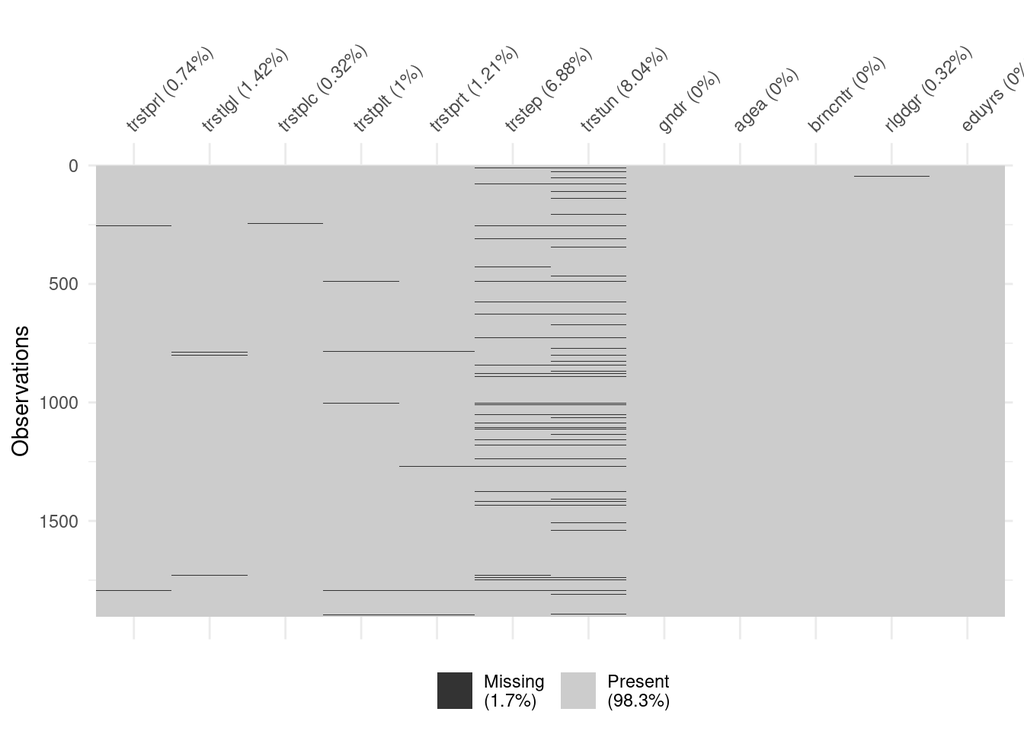

```r
vis_miss(andmed) # Andmelünkade esinemine andmestikus andmeid tunnuste väärtuste järgi sorteerimata
```

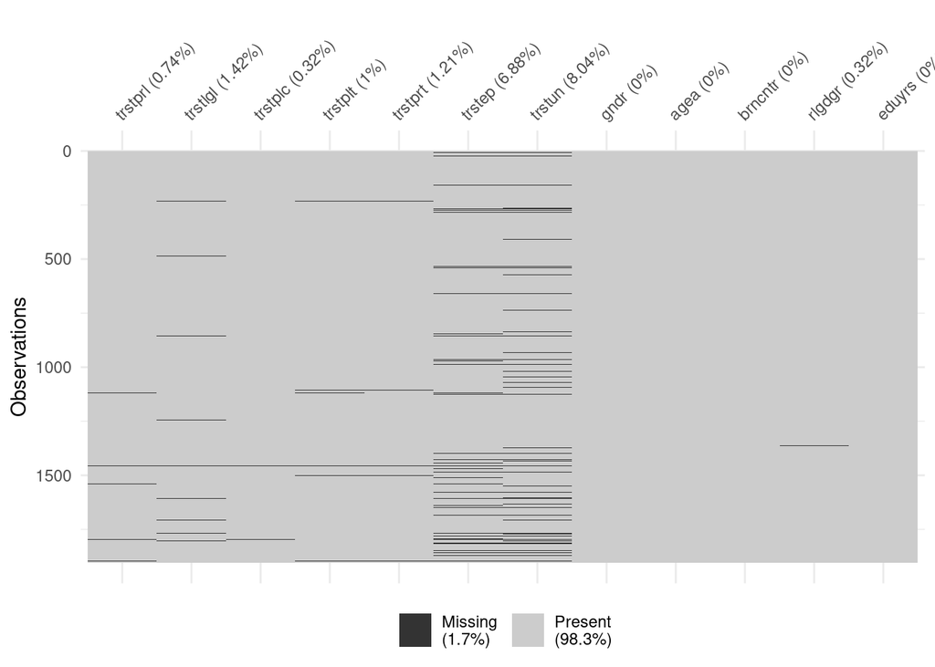

```r
vis_miss(arrange(andmed,agea)) # Andmelünkande esinemine andmestikus sorteerides andmeid vanuse järgi
```

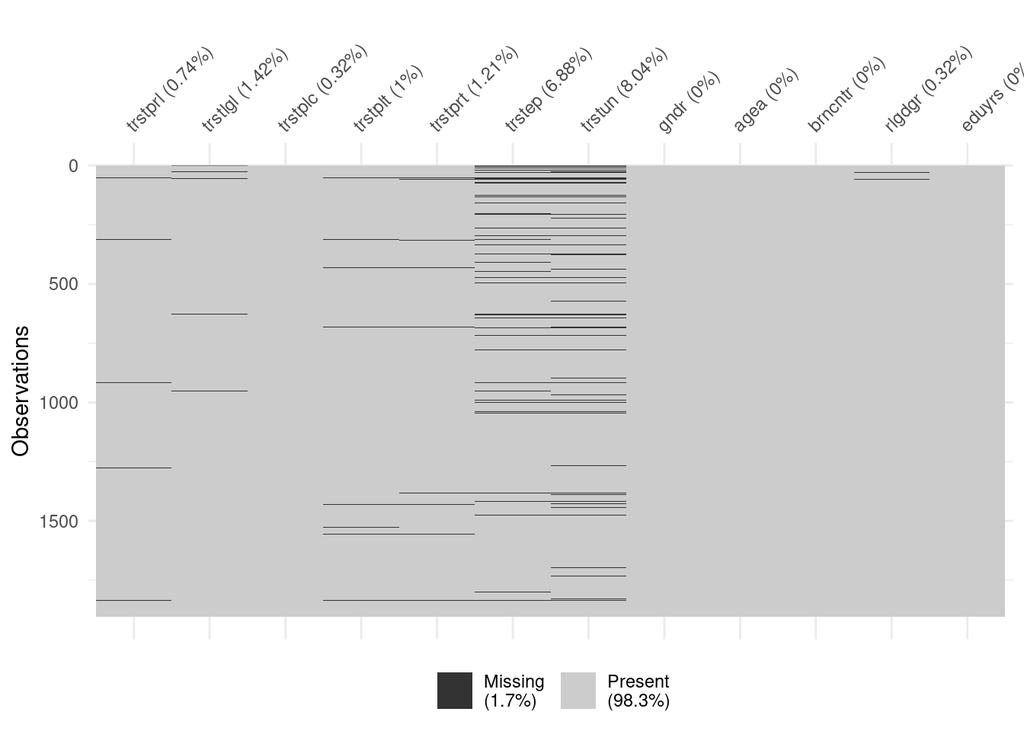

```r
vis_miss(arrange(andmed,eduyrs)) # Andmelünkande esinemine andmestikus sorteerides andmeid haridustee pikkuse järgi
```

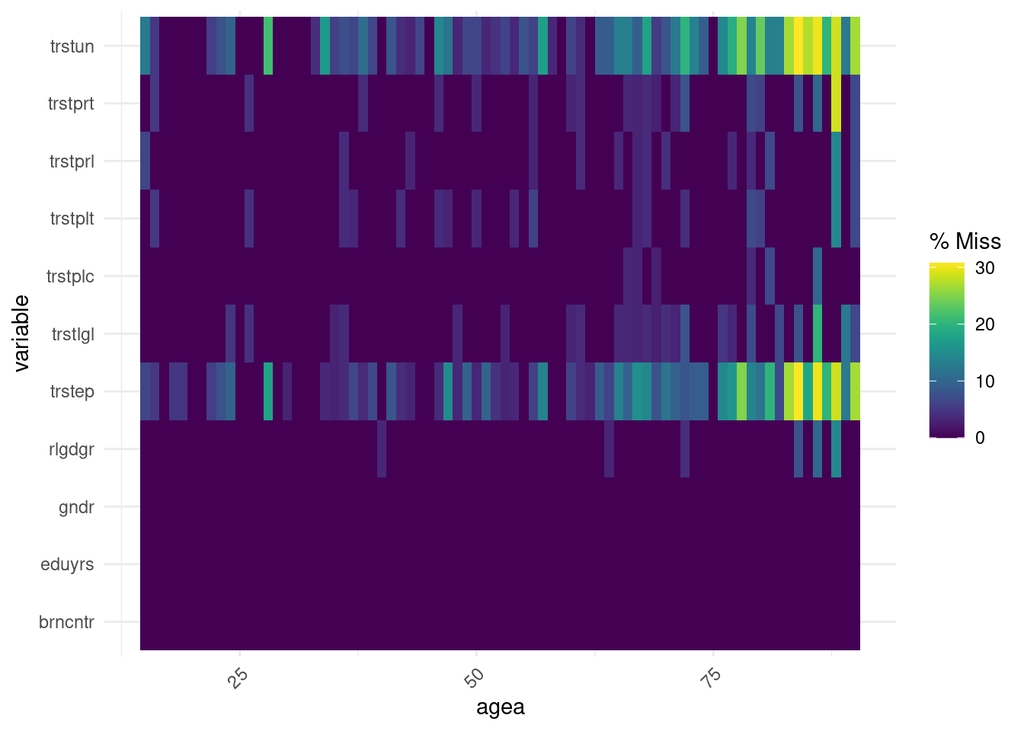

```r
# Parema visuaali annaks minu arvates hoopis gg_miss_fct funktsiooni kasutamine:
gg_miss_fct(andmed, fct=agea)
```

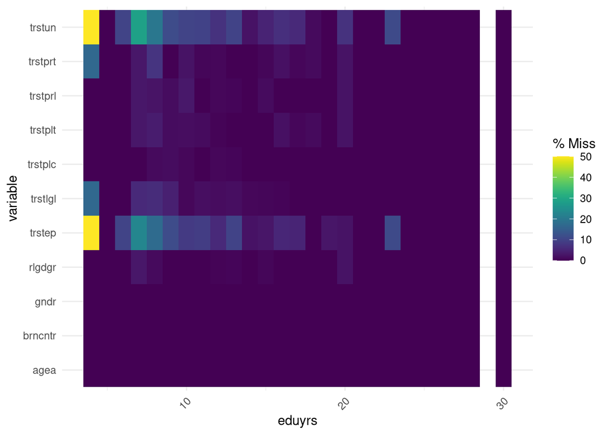

```r
gg_miss_fct(andmed, fct=eduyrs)
```

**Vastus:** Üldistades võib öelda, et andmelünki esineb rohkem vanemate ja lühema haridusteega vastajate puhul.

**Praktikumis uurisime lünklikkuse mustreid funktsiooniga gg_miss_upset. Leidke seda funktsiooni kasutades, kui palju tõuseks iga üksiku tunnuse väljajätmisel täisvastustega indiviidide arv. Milliste tunnuste väljajätmisest oleks täisvastustega indiviidide arvu suurenemise mõttes kõige rohkem kasu?**

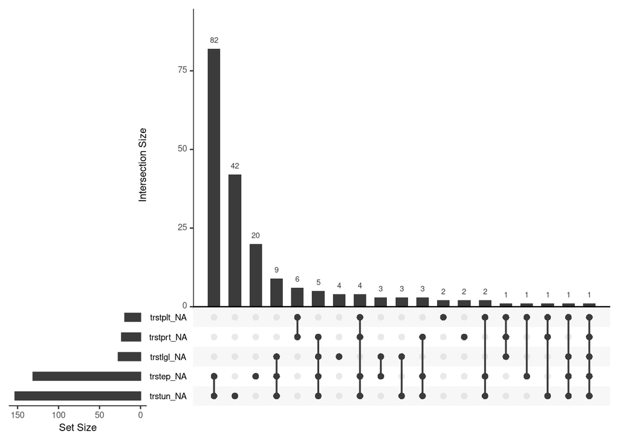

```r
gg_miss_upset(andmed)
```

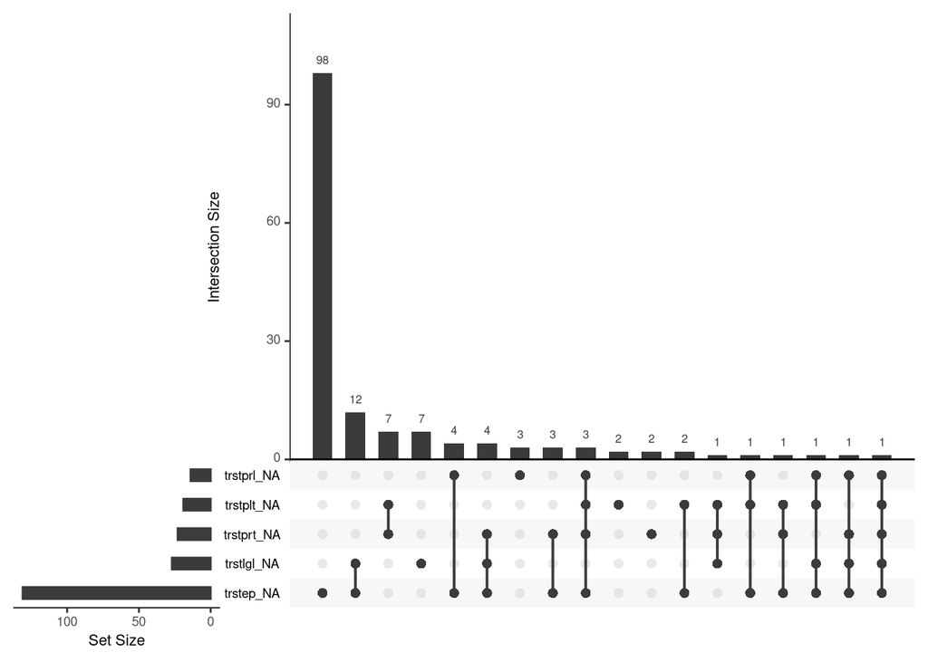

```r
andmed %>%
  select(-trstun) %>%
  gg_miss_upset()
```

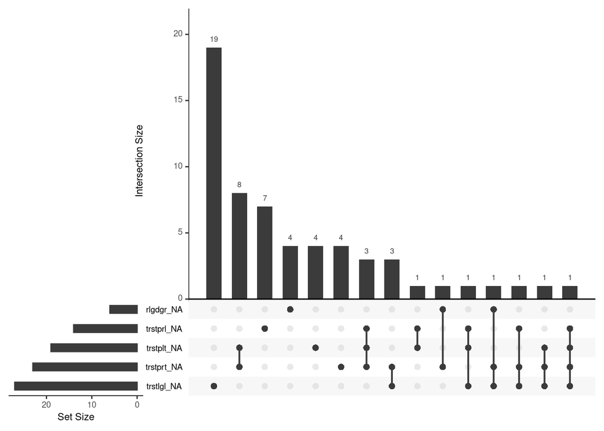

```r
andmed %>%
  select(-trstep) %>%
  select(-trstun) %>%
  gg_miss_upset()
```

**Vastus:** Esimesel gg_miss_upset() funktsiooniga tehtud joonisel on näha, et kõige rohkem kasu oleks *tsrtun* (usaldus ÜRO vastu) ja *trstep* (usadus Euroopa Parlamendi vastu) tunnuste väljajätmisest. 82 vastajal on andmelüngad nende mõlema tunnuse puhul. Ainult *trstun* tunnuses on andmelüngad 42 vastajal ja ainult *trstep* tunnuses on andmelüngad 20 vastajal. Nende mõlema tunnuse välja jätmisel kasvaks täisvastustega indiviidide arv 144 võrra. Ainult *trstlgl* (usaldus õigussüsteemi vastu) tunnuse puhul on andmelüngad neljal vastajal. Teisel gg_miss_upset() funktsiooniga tehtud joonisel on näha, et kui jätta välja *trstun* tunnus, siis oleks suurima lünklikkusega *tsrtep* tunnus (98 andmelünka) ja kolmandal joonisel on näha, et kui jätta välja mõlemad, *tsrtep* ja *trstun* tunnus, siis oleks kõige rohkem andmelünki tunnuses *trstlgl* (19 andmelünka).

**Uurige kahe kõige suurema lünklikkusega tunnuse puhul, kas nende lünklikkus on seotud soo, vanuse, Eestis sündimise, usklikkuse või haridustee pikkusega või võiksid nendes kahes tunnuses esinevad lüngad olla täiesti juhuslikud (MCAR) . Uurige seda kõigepealt visuaalselt ja seejärel funktsiooniga missing_compare keskmiste, risttabelite ja statistiliste testide põhjal. Mida järeldate - kas andmelünkadega indiviidid võiks lihtsalt südamerahuga eemaldada? Kui seda teha, mida peaks edasises analüüsis (nt uurides seoseid nende tunnuste vahel) tulemuste tõlgendamisel arvesse võtma?**

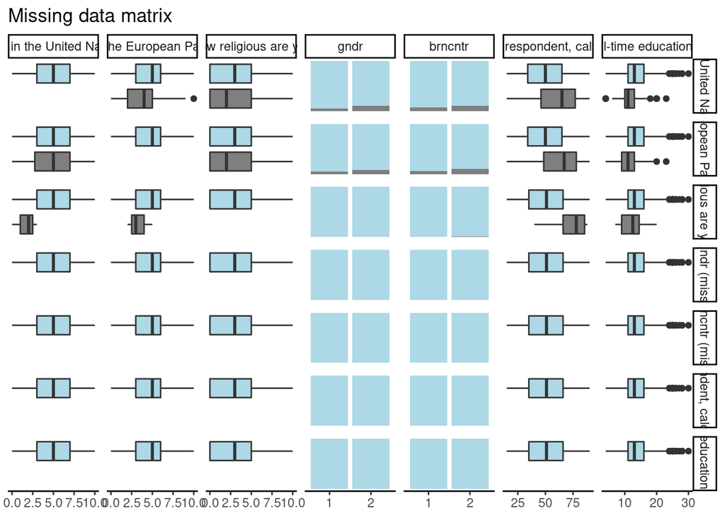

```r
andmed$gndr <- as.factor(andmed$gndr)
andmed$brncntr <- as.factor(andmed$brncntr)

missing_pairs(andmed,
              explanatory = c("trstun","trstep","rlgdgr","gndr","brncntr","agea","eduyrs"),
              position = "fill")
```

```r
missing_compare(andmed,
                dependent="trstep",
                explanatory=c("rlgdgr","gndr","brncntr","agea","eduyrs")) %>%
  knitr::kable(row.names=FALSE, align = c("l", "l", "r", "r", "r"))
```

| Missing data analysis: Trust in the European Parliament |  | Not missing | Missing | p |
| --- | --- | --- | --- | --- |
| How religious are you | Mean (SD) | 3.3 (3.1) | 2.9 (3.3) | 0.134 |
| gndr | 1 | 798 (95.3) | 39 (4.7) | 0.001 |
|  | 2 | 975 (91.4) | 92 (8.6) |  |
| brncntr | 1 | 1538 (93.7) | 104 (6.3) | 0.026 |
|  | 2 | 235 (89.7) | 27 (10.3) |  |
| Age of respondent, calculated | Mean (SD) | 49.9 (19.0) | 62.1 (19.8) | <0.001 |
| Years of full-time education completed | Mean (SD) | 13.5 (3.5) | 11.6 (3.3) | <0.001 |

```r
missing_compare(andmed,
                dependent="trstun",
                explanatory=c("rlgdgr","gndr","brncntr","agea","eduyrs")) %>%
  knitr::kable(row.names=FALSE, align = c("l", "l", "r", "r", "r"))
```

| Missing data analysis: Trust in the United Nations |  | Not missing | Missing | p |
| --- | --- | --- | --- | --- |
| How religious are you | Mean (SD) | 3.3 (3.1) | 3.0 (3.3) | 0.315 |
| gndr | 1 | 796 (95.1) | 41 (4.9) | <0.001 |
|  | 2 | 955 (89.5) | 112 (10.5) |  |
| brncntr | 1 | 1518 (92.4) | 124 (7.6) | 0.068 |
|  | 2 | 233 (88.9) | 29 (11.1) |  |
| Age of respondent, calculated | Mean (SD) | 49.8 (19.0) | 61.0 (19.7) | <0.001 |
| Years of full-time education completed | Mean (SD) | 13.5 (3.5) | 11.7 (3.4) | <0.001 |

**Vastus:** Ei saa väita, et lüngad oleksid täiesti juhuslikud (MCAR), kuna missing_compare funktsiooni kasutades selgub, et andmelünkade puhul esinevad seosed soo, vanuse ja haridustee pikkusega. Tunnuse *trstep* puhul on näha, et andmelünki esineb rohkem naistel kui meestel. 92 naist jättis sellele küsimusele vastamata (8.6% kõigi uuringus osalenud naiste arvust). Samas jättis küsimusele vastamata vaid 39 meest (4.7% kõigist uuringus osalenud meestest). Samuti on mõnevõrra oluline ka seos Eestis sündimise ja tunnusele *trstep* vastamata jätmise vahel: andmelünki esines 6.3% Eestis sündinud indiviidil (104 inimesel 1642-st), aga 10.3% mujal sündinud indiviidil (27 inimesel 262-st). Seosed on ka vanuse ja haridustee pikkuse ning tunnuse *trstep* puudumise vahel. Keskmine uuringus osaleja vanus tunnuses *trstep* andmelünga esinemise puhul on 62.1 aastat, küsimusele vastajate puhul on keskmine vanus 49.9 aastat. Haridustee pikkus on küsimusele vastajate puhul keskmiselt 13.5 aastat ja mittevastajate puhul 11.6 aastat. Seega saab väita, et küsimusele jätsid vastamata pigem vanemad, lühema haridusteega ja mitte Eestis sündinud naised. Olulisuse tõenäosus kõigi nelja seotud tunnuse puhul on p<0.026. Ka tunnuse *trstun* puhul on näha sarnaseid seoseid. 10.5% kõigist naistest (112 naist), aga ainult 4.9% kõigist meestest (41 meest) jättis küsimusele vastamata. Samuti on näha, et vastajate keskmine vanus oli 49.8 aastat vs mittevastajate 61 aastat. Haridustee pikkus oli vastajate puhul keskmiselt 13.5 aastat ja mittevastajatel 11.7 aastat. Seega saaks väita, et küsimusele jätsid vastamata pigem lühema haridusteega ja vanemad naised. Olulisuse tõenäosus kõigi kolme seotud tunnuse puhul: p<0.001. Kuna eelnevast võib järeldada, et lüngad ei ole täiesti juhuslikud (MCAR), siis ei ole neid võimalik ka lihtsalt eemaldada mõjutamata sellega edasist uuringu tulemuste tõlgendamist.